# Creating a Basic CTA Bus Tracker

Isaac Rand

4/22/2020

## Setup

To make this tracker we’re going to be using several packages and libraries libraries. Install and load them using the code here:

```r
### package install -- skip this if you already have the packages needed

# install.packages("sf")  #this package allows us to use spatial data
# install.packages("dplyr")   #this package lets us code prettily :)
# install.packages("jsonlite")   #this package lets us handle JSON data received from the CTA bus tracker API
# install.packages("leaflet")   #this package provides nice basemaps
# install.packages("ggmap")     #this package allows for nice mapping of spatial data

# Loading libraries -- don't skip this!
library(sf)
library(dplyr)
library(jsonlite)
library(leaflet)
library(ggmap)
```

## Getting the data

### Getting the Attribute Data

The first step is registering for an API key for [CTA Bus Tracker](https://www.transitchicago.com/developers/bustracker/). The Bus Tracker has a lot of different functionality (including the ability to track trains) but for now we’re just going to use its ability to return information on all the vehicles running specified routes.

The following code retrieves information about the buses currently running as a 55, 59, 63, and 6 bus. To get the data for whatever bus routes you like, change the rt parameter list (in the URL) from 55,59,63,6 to include whatever your preferred routes are. Make sure you remember to replace the key parameter with your own API Key!

```r
busAttDataDirty <- fromJSON(txt = "http://www.ctabustracker.com/bustime/api/v2/getvehicles?format=json&rt=55,59,63,6&key=YOURKEYHERE")
```

The information we actually want is currently saved wrapped up in an extra list. The following code extracts the data from its wrappers and puts it into a nice to work with data frame:

```r
busAttDataClean <- as.data.frame(busAttDataDirty$`bustime-response`$vehicle)
```

### Converting to Spatial Data

In order to turn the attribute data into spatial data, we need to use the `sf` library’s `st_as_sf()` function. This function allows us to convert our data frame into an `sf` object with the latitude and longitude coordinates downloaded from the CTA bus tracker API defining the location of each point, instead of just existing as numbers.

Note that the CTA uses the WGS 84 projection (crs 4326). If you are using a different data source, you may need to change the crs data parameter here and in later sections of this process.

```r
busDataSpatial = st_as_sf(busAttDataClean, coords = c("lon", "lat"),
                 crs = 4326, agr = "constant")
```

## Mapping

### Plotting a Base Map

A base map is a very useful tool to show where the data actually is. Without it, all of the points we have generated so far would turn up in white space with no context at all, and not be very helpful to anyone – like this:

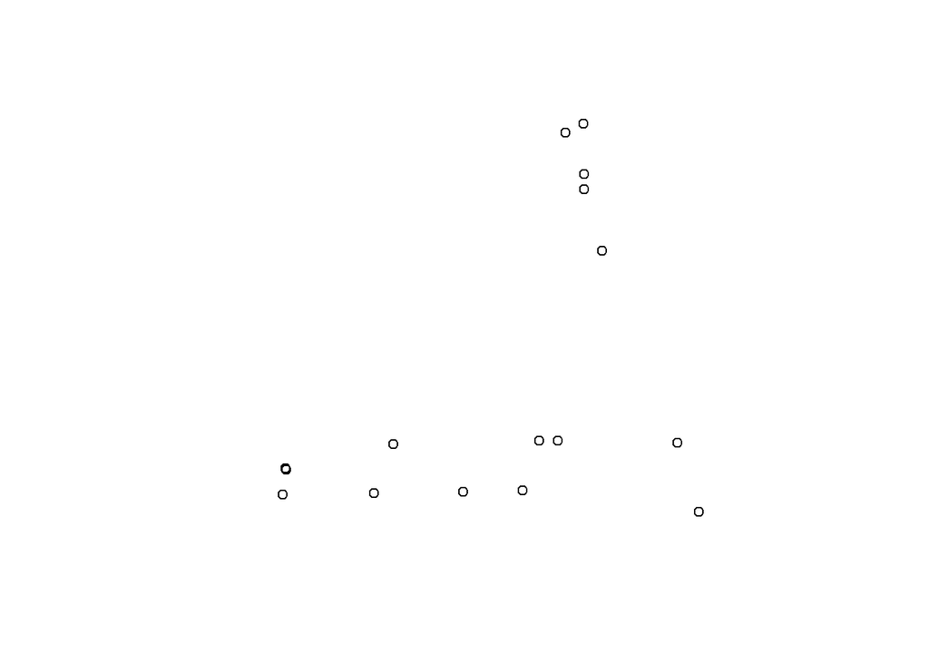

```r
plot(st_geometry(busDataSpatial))
```

We can use the Leaflet library to plot many different kinds of basemaps. This type of map is especially nice because it allows users to zoom in and out on their own without much work on our end at all. You can generate a map of Chicago using the code below :)

```r
leafletMap <- leaflet(busDataSpatial) %>%

    setView(-87.628170, 41.876216, 10) %>%    # this sets the center of the map to (41.876216, -89.628170) and the zoom level to 10 (0 is all the way out, 18 is all the way in)

    addTiles()                            # this draws the basemap provided by Open Street Map

leafletMap
```

[interactive chart not shown]

### Adding Data to the Base Map

For this next part it is important how we declared `leafletMap` above. When we first called `leaflet()`, we passed it `busDataSpatial` as a parameter. This means that `leafletMap` has access to the data already, and all we have to do is add markers for each point.

Leaflet has a ton of cuztomization options available. Here, I show changing the point’s radius (as the default was much too large), setting the color based on the route so that buses can be easily told apart, and adding a legend so viewers no which route is which.

```r
pal <- colorFactor(c("navy", "red", "green", "yellow"), domain = c("6", "55", "59", "63"))
leafletMap <- leafletMap %>%
  addCircleMarkers(radius = 1, color =  ~pal(rt)) %>%
  addLegend("bottomright", pal = pal, values = ~rt,
    title = "Bus Routes",
    opacity = 1
  )
leafletMap
```

[interactive chart not shown]

That’s it! You now have a basic CTA Bus Tracker! Every time you re-run the code (with a minute or two lag in between for the CTA to catch up), you will see the map update with new bus location data.